# The Coronavirus’s Effect on Air Travels and the Implications

By: Monica Dao (xmtdx@uw.edu), John Oh (jho12@uw.edu), Garima Thapa (gt35@uw.edu), Linda Giang (linda71@uw.edu)

**INFO-201: Technical Foundations of Informatics - The Information School - University of Washington WINTER 2022**

## Report

### Abstract

Our main question is how COVID has affected air travel and how this impacts the lives of the people that travel. This question is important because COVID has caused many losses for airlines with many people opting for other options to connect with others. To help answer this question, we will find details on the changes in passengers that the airlines receive.

### 1. Introduction

The coronavirus that has rapidly spread since early 2020 caused many to be apprehensive towards crowds of people. Airplanes are examples of this, being an enclosed space that seats many people for an average of 3 hours. Due to such concerns, airlines have been seeing a decline in business since March of 2020, with many countries adding travel bans and restrictions. With the introduction of vaccines and safety practices, many are starting to travel by air again. An initial study conducted by the Harvard T.H. Chan School of Public Health concluded that “there is a low risk of COVID-19 transmission on aircraft” [(Barnes, 2020)](https://www.ustravel.org/news/harvard-study-low-risk-COVID-19-transmission-when-flying)[^1] as of October 2020. However, with the new COVID Omicron variant, the recovery of airline businesses may continue to see limited passengers. There are articles where an airline medical advisor predicted that Omicron will make it “twice or even three times more likely to catch COVID-19 during a flight” [(Whitley, 2021)](https://www.bloomberg.com/news/articles/2021-12-22/omicron-at-least-doubles-risk-of-getting-infected-on-a-plane)[^2]. The trends of passengers may inversely follow the number of cases, but with the effectiveness of the vaccines and the addition of the booster, this may not have to be the case.

### 2. Design Situation

#### Framing the topic of concern

Air travel is one of the most prevalent ways of traveling, and it has impacted the way people plan long-term and short-term travel in the United States. But in 2020, COVID-19 has changed the behaviors of people that existed since airlines have become commercialized, which shows the severity COVID-19 had on people’s lives. Not only did it change the behavior of people on using commercial airlines, but it also changed the behavior of airlines, “reducing Domestic departures declined 71.5% in May 2020 as compared to the previous year” [(Hotle, 2020)](https://www.sciencedirect.com/science/article/pii/S2590198220301883)[^3]. Our topic, using air travel data, will present how impactful COVID-19 was to this society by analyzing the behavioral changes of people and airlines during 2020.

#### Human Values

There are many reasons behind deciding to opt-out of airline traveling, which one may argue is due to safety concerns. However, this decision goes beyond just safety and is related to unemployment, uncertainty, and psychological hindrance due to COVID-19. For example, in 2020 unemployment in the U.S. rose about 100% from the previous year (Bureau of Labor Statistics, 2021)[^4]. Such data shows the priority of the people and their values in safety, which originates from deaths and over-hospitalization due to COVID-19.

#### Stakeholders

The direct stakeholders are airports and airlines. Airlines worldwide suffered a -$137.7 billion in net loss post COVID during 2020, showing the significant impact COVID had on airline profits [(Mazareanu, 2021)](https://www.statista.com/statistics/232513/net-profit-of-commercial-airlines-worldwide/#:~:text=In%202020%2C%20the%20U.S.%20airline,only%20130.85%20billion%20U.S.%20dollars.)[^5]. Any workers of airports and airlines can suffer financial damage from traveling decline, making our data an important part of their operation. Indirect stakeholders are those who wish to travel either for business or personal reasons, as rising in COVID-19 would limit them from using air traveling as an option.

#### Benefits and Harms

A benefit of having COVID-19 and Air-travel history data is its sensitivity to trends. Both data can be generally analyzed before significant outbreaks, which means actions can be taken based on an increasing trend in COVID-19 and decreasing trend in air travel, limiting the chance of compromising people’s safety when traveling. Airline workers are able to avoid being in a dangerous situation. However, these data often change drastically throughout periods, creating unpredictability when actions are needed. This could create confusion amongst decision-makers in the airline industry regarding air travel operations, which may contradict policy makers’ decisions.

### 3. Research questions

- How have COVID impacted the density of passengers in the various airlines? Are the effects applicable across the airlines? If not, why is that the case?
- What are the general passenger’s reasons for traveling and how has such purposes shifted during the pandemic?
- How has the destination frequency of the airlines shifted throughout the pandemic? What seems to be the reason for such shifts?
- How have the airlines operated to minimize losses and retain customers?
- What does the data being an international report of passengers say about COVID’s impact on international travels? How would this affect people living abroad?

Many adjustments had to be made in the daily lives of people including how they interact with people who live far away with them. With airplanes being an enclosed space and passengers seated in close proximity, the risks of COVID is increased. Therefore these questions seek to find out how people have been using the various airlines while lessening their risk of COVID. We would like to find out whether the airline businesses will stay limited or if people have decided that it’s safer to travel now that vaccines, masks, and disinfections have become more common. The changes in usage of these various airlines can also seek to optimize the usage of planes and decrease the greenhouse gas produced. In 2019, it was seen that 29% of carbon pollution came from the transportation sector [(Sources of Greenhouse Gas Emissions, 2021)](https://www.epa.gov/ghgemissions/sources-greenhouse-gas-emissions#transportation)[^6].

### 4. The Dataset

The dataset is U.S. International Air Traffic data(1990-2020) from Kaggle[^7] on airport and airline traffic by US and international carriers. The data, held in the U.S. Department of Transportation[^8] website, is from the [U.S. International Air Passenger and Freight Statistics Report](https://www.transportation.gov/policy/aviation-policy/us-international-air-passenger-and-freight-statistics-report)[^9] page. This particular dataset is on passengers and holds information on the number of passengers each month and year between two airports serviced by a specific airline. This report is part of the T-100 program and it was developed to allow the public to have access to data on flights internationally. The dataset reports are updated quarterly, and the site has multiple datasets around Passenger, Freight, Departures, Seats. The effect of the pandemic on traffic can be analyzed in the 2020 report.

The T-100 program by the USDOT began on January 1, 1990. It produces reports of foreign airlines operating to and from the United States and traffic reports of both domestic and international operations of U.S. airlines. The reports are submitted by airlines to the Department’s Office of Airline Information of the Bureau of Transportation Statistics. There is a rule that states that data must be confidential for 6 months before reporting.

This dataset is very large and has over 680k rows and 16 columns. Columns are labeled as: data_dte (data date), Year (data year), Month (Data month), usg_apt_id (US Gateway airport ID), usg_apt (US Gateway airport code), usg_wac (US Gateway World area code, to represent a geographic territory), fg_apt_id (Foreign Gateway Airport ID), fg_apt (Foreign Gateway Airport code), fg_wac (Foreign Gateway world area code), airlineid (Airline ID), carrier (IATA assigned air carrier code), carriergroup (Carrier Group Code – 1 denotes US domestic air carrier, 0 is foreign), type (Passengers), Scheduled (metric flown by scheduled service operations), Charter (metric flown by charter operations), and Total (total metric flown by scheduled service and charter operations).

This dataset contains all nonstop commercial passenger traffic traveling between international points and U.S. airports. The data covers the timeline between January 1, 1990 to March 1, 2020. This dataset does not cover all aspects of international travel as nonstop traffic to and from U.S. cities that serve as international gateway will have high numbers.

It should be noted that some traffic continues on a connecting flight due to most international passengers having at least one connecting flight before reaching their final destination. U.S. carriers also serve some international points through an international connection only. Although the data can seem to show that no U.S. carrier serves an international point, the carrier traffic is first moving through a connecting city. There are influences of code-share agreements on this data, and this agreement makes it common for passengers to fly on an aircraft operated by an airline different from the one they bought their ticket from.

### 5. Expected implications

A possible implication for policymakers would be the level of enforcement or lift on travel restrictions. As of right now, different states have different travel policies regarding COVID-19, which are in place by the decision of the policymaker in each state. For technologists, it is expected that they will develop more technology in recording the effects of COVID on air travel as our analysis elaborates on how COVID has drastically affected our lives. Another possible implication for technologists would be creating more cost-friendly travel services to minimize losses since fewer people have been traveling. Additionally, we can expect designers to design better ways to make it easier to connect with distanced friends and family without requiring travel by air. Since people are missing out on the in-person experience because of the spread of COVID, designers may improve activities so that people can still enjoy each other from afar.

### 6. Limitations

The database we will be using, COVID-19 Daily Data Updated [(Affan, n.d.)](https://www.kaggle.com/affanazhar/COVID19-daily-data-updated/version/6?select=COVID_19_data_version_6.csv)[^10], has updates up to January 30, 2022. Although this information is recent, the latest data records numbers at the peak of reported COVID-19 cases, which may not be an accurate representation of the present-day situation. The statistics provided by the New York Times show that the seven-day average of COVID cases reported on January 30, 2022, is 522,965 cases whereas, on February 3, 2022, it is 356,849 cases [(Washington Coronavirus Map and Case Count, 2022)](https://www.nytimes.com/interactive/2021/us/washington-COVID-cases.html)[^11]. Because the numbers are changing drastically as each day passes, our data and research may not be as predictive of the future as we hope. In addition to that, the dataset may not be as accurate since we only have the number of COVID cases reported and not the true number of COVID cases throughout the United States.

### Acknowledgement

Thanks to the people who took the time to collect the data that allowed us to do an insightful research for our project. Also thanks to T.A. Samuel for giving us clear instructions and guidance that helped us initiate the project.

### Summary Information

Airline with Most Flights (popular): `AA` = Alaska Airlines

Percentage Difference in Passengers 2019-2020: `-21.4320374`%

Year with Most Passengers: `2019`

Day with Lowest Average Passengers: `1991-02-01`

### Aggregate Table

| janurary_to_march_each_year | total_passengers | percent_total | percent_increase |
| --- | --- | --- | --- |
| 1990 | 19141361 | 1.77 | NA |
| 1991 | 16913723 | 1.57 | -11.64 |
| 1992 | 20404527 | 1.89 | 20.64 |
| 1993 | 21539315 | 2.00 | 5.56 |
| 1994 | 22633170 | 2.10 | 5.08 |
| 1995 | 23469296 | 2.17 | 3.69 |
| 1996 | 26200744 | 2.43 | 11.64 |
| 1997 | 28004770 | 2.59 | 6.89 |
| 1998 | 28953119 | 2.68 | 3.39 |
| 1999 | 30599993 | 2.83 | 5.69 |
| 2000 | 32461609 | 3.01 | 6.08 |
| 2001 | 33509216 | 3.10 | 3.23 |
| 2002 | 28858180 | 2.67 | -13.88 |
| 2003 | 29716102 | 2.75 | 2.97 |
| 2004 | 32734261 | 3.03 | 10.16 |
| 2005 | 35748704 | 3.31 | 9.21 |
| 2006 | 35980607 | 3.33 | 0.65 |
| 2007 | 37016777 | 3.43 | 2.88 |
| 2008 | 39437616 | 3.65 | 6.54 |
| 2009 | 35293441 | 3.27 | -10.51 |
| 2010 | 36763097 | 3.41 | 4.16 |
| 2011 | 37787445 | 3.50 | 2.79 |
| 2012 | 40032706 | 3.71 | 5.94 |
| 2013 | 41745104 | 3.87 | 4.28 |
| 2014 | 43510328 | 4.03 | 4.23 |
| 2015 | 45859482 | 4.25 | 5.40 |
| 2016 | 49512926 | 4.59 | 7.97 |
| 2017 | 51318601 | 4.75 | 3.65 |
| 2018 | 54589016 | 5.06 | 6.37 |
| 2019 | 55941359 | 5.18 | 2.48 |
| 2020 | 43951986 | 4.07 | -21.43 |

This table was included to show the impact of Covid-19 on airline passengers. Since the 1990s, excluding January through March of 1991, 2002, and 2009, which had minor decrease in passengers count at about 10%, the first three months of every other years had a steady increase in passengers count from the previous year. However, in 2020, there was a greatest decrease at about 21%, which most likely was caused by the impact of global pandemic which shutdown most of airline operations. In terms of the ratio between the January to March passenger count of 2020 and the total passenger counts since 1990, the total percentage is average at about 4%, which shows that even though the airline industries has grown significantly since the past and more people are using airlines than ever, Covid-19 still had a big impact on the industry; this proves how impactful Covid-19 was and is to the whole world.

### Charts

##### Visual 1

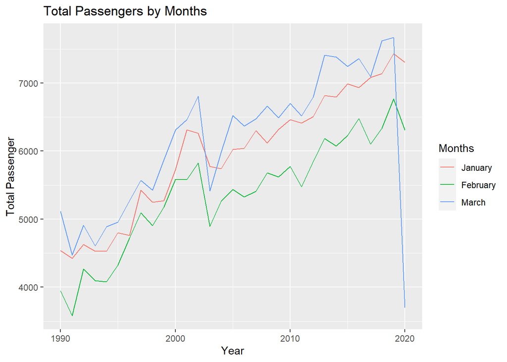

The amount of passengers is mapped out to show the changes throughout the year. This line graph contains 3 separate lines that correlate to the first 3 months of the year. By being able to visualize the data by month, the changes in passenger density because there are holidays and events within certain months. This separation also allows for the visualized graph to have clearer relationships, outlining the **sharp decline in passengers at March of 2020** as calculated from the second function. Besides the decrease that occurred in March, **the data prior had a general positive trend, the increase and decrease of passenger density of each month is generally relative to one another**.

##### Visual 2

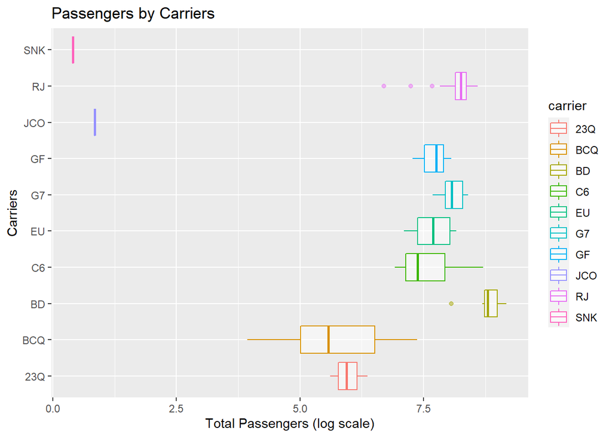

[figure not shown]

This chart shows the changes in the total passengers by each carrier, each of the totals were calculated based on the year. This chart was made to help judge the range and consistency of each of the carriers, and whether or not there were large shifts between the years. Given that the number of carriers add up to over 500, the data set is set to take in the data of 10 different carriers to calculate the distributions in passengers. It can be seen that **some airlines contain outliers, while some are highly compact and close to the it’s average total passengers**.

[figure not shown]

##### Visual 3

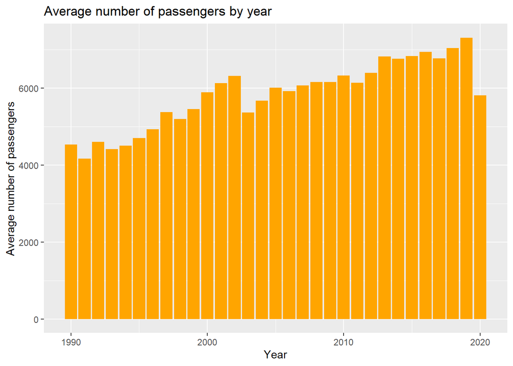

Chart 3 shows the average number of passengers by year throughout the years (1990-2020). The histogram was made to help show the frequency in air travel by the year with the past decade and provide insight into relationships between major events and frequency of air travel. The visualizations in bars (the height) shows **a drastic decrease in number of passengers in 2020 when the years before show an overall increasing trend**. This reveals that there may have been a major event to have caused an abrupt drop in the average number of airline passengers.

### References

[^1]: Barnes, T. E. (2020, October 29). *Harvard Study: ‘Low Risk’ of COVID-19 Transmission When Flying.* US Travel Association. Retrieved February 4, 2022, from https://www.ustravel.org/news/harvard-study-low-risk-covid-19-transmission-when-flying
[^2]: Whitley, A. (2021, December 22). *Is It Safe to Fly Right Now? Omicron May Double Infection Risk on Planes: IATA.* Bloomberg.com. Retrieved February 4, 2022, from https://www.bloomberg.com/news/articles/2021-12-22/omicron-at-least-doubles-risk-of-getting-infected-on-a-plane
[^3]: Hotle, S., & Mumbower, S. (2020, December 9). *The impact of covid-19 on domestic U.S. Air Travel Operations and commercial airport service.* Transportation Research Interdisciplinary Perspectives. Retrieved February 4, 2022, from https://www.sciencedirect.com/science/article/pii/S2590198220301883
[^4]: U.S. Bureau of Labor Statistics. (n.d.). *Unemployment rises in 2020, as the country battles the COVID-19 pandemic : Monthly Labor Review.* U.S. Bureau of Labor Statistics. Retrieved February 4, 2022, from https://www.bls.gov/opub/mlr/2021/article/unemployment-rises-in-2020-as-the-country-battles-the-covid-19-pandemic.htm#:~:text=June%202021-,Unemployment%20rises%20in%202020%2C%20as%20the,battles%20the%20COVID%2D19%20pandemic&text=Total%20civilian%20employment%2C%20as%20measured,3.6%20percent%20to%2013.0%20percent.
[^5]: Mazareanu, E. (2021, October 5). *Net profit of airlines worldwide 2006-2022.* Statista. Retrieved February 4, 2022, from https://www.statista.com/statistics/232513/net-profit-of-commercial-airlines-worldwide/#:~:text=In%202020%2C%20the%20U.S.%20airline,only%20130.85%20billion%20U.S.%20dollars.
[^6]: “Sources of Greenhouse Gas Emissions.” *EPA*, Environmental Protection Agency, 27 July 2021, https://www.epa.gov/ghgemissions/sources-greenhouse-gas-emissions#transportation.
[^7]: Pandey, P. (2021, July 16). *U.S. International Air Traffic Data(1990-2020)*. Kaggle. Retrieved February 4, 2022, from https://www.kaggle.com/parulpandey/us-international-air-traffic-data?select=International_Report_Passengers.csv
[^8]: Department of Transportation Office of the Assistant Secretary for Aviation and International Affairs. (2022, January 7). *International_Report_Passengers*. data.transportation.gov. Retrieved February 4, 2022, from https://data.transportation.gov/Aviation/International_Report_Passengers/xgub-n9bw
[^9]: U.S. International Air Passenger and Freight Statistics Report. U.S. Department of Transportation. (2022, January 7). Retrieved February 4, 2022, from https://www.transportation.gov/policy/aviation-policy/us-international-air-passenger-and-freight-statistics-report
[^10]: Affan, M. (2022, January 30). *COVID-19 Daily data Updated.* https://www.kaggle.com/affanazhar/covid19-daily-data-updated/version/6?select=covid_19_data_version_6.csv
[^11]: *Washington Coronavirus Map and Case Count.* (2022, February). The New York Times. Retrieved February 4, 2022, from https://www.nytimes.com/interactive/2021/us/washington-covid-cases.html